# Exercise solutions: Section 10.8

Rob J Hyndman and George Athanasopoulos

# Ex 1

> Write out the $\mathbf{S}$ matrices for the Australian tourism hierarchy and the Australian prison grouped structure. Use the `smatrix` command to verify your answers.

## Tourism hierarchy

The $\mathbf{S}$ matrix is
$$\begin{bmatrix}
1 1 1 1 1 1 1 1 1 1 1 1 1 1 1 1 1 1 1 1 \\
1 1 1 1 1 0 0 0 0 0 0 0 0 0 0 0 0 0 0 0 \\
0 0 0 0 0 1 1 0 0 0 0 0 0 0 0 0 0 0 0 0 \\
0 0 0 0 0 0 0 1 1 1 0 0 0 0 0 0 0 0 0 0 \\
0 0 0 0 0 0 0 0 0 0 1 1 1 0 0 0 0 0 0 0 \\
0 0 0 0 0 0 0 0 0 0 0 0 0 1 1 1 1 0 0 0 \\
0 0 0 0 0 0 0 0 0 0 0 0 0 0 0 0 0 1 1 1 \\
1 0 0 0 0 0 0 0 0 0 0 0 0 0 0 0 0 0 0 0 \\
0 1 0 0 0 0 0 0 0 0 0 0 0 0 0 0 0 0 0 0 \\
0 0 1 0 0 0 0 0 0 0 0 0 0 0 0 0 0 0 0 0 \\
0 0 0 1 0 0 0 0 0 0 0 0 0 0 0 0 0 0 0 0 \\
0 0 0 0 1 0 0 0 0 0 0 0 0 0 0 0 0 0 0 0 \\
0 0 0 0 0 1 0 0 0 0 0 0 0 0 0 0 0 0 0 0 \\
0 0 0 0 0 0 1 0 0 0 0 0 0 0 0 0 0 0 0 0 \\
0 0 0 0 0 0 0 1 0 0 0 0 0 0 0 0 0 0 0 0 \\
0 0 0 0 0 0 0 0 1 0 0 0 0 0 0 0 0 0 0 0 \\
0 0 0 0 0 0 0 0 0 1 0 0 0 0 0 0 0 0 0 0 \\
0 0 0 0 0 0 0 0 0 0 1 0 0 0 0 0 0 0 0 0 \\
0 0 0 0 0 0 0 0 0 0 0 1 0 0 0 0 0 0 0 0 \\
0 0 0 0 0 0 0 0 0 0 0 0 1 0 0 0 0 0 0 0 \\
0 0 0 0 0 0 0 0 0 0 0 0 0 1 0 0 0 0 0 0 \\
0 0 0 0 0 0 0 0 0 0 0 0 0 0 1 0 0 0 0 0 \\
0 0 0 0 0 0 0 0 0 0 0 0 0 0 0 1 0 0 0 0 \\
0 0 0 0 0 0 0 0 0 0 0 0 0 0 0 0 1 0 0 0 \\
0 0 0 0 0 0 0 0 0 0 0 0 0 0 0 0 0 1 0 0 \\
0 0 0 0 0 0 0 0 0 0 0 0 0 0 0 0 0 0 1 0 \\
0 0 0 0 0 0 0 0 0 0 0 0 0 0 0 0 0 0 0 1
\end{bmatrix}$$

The bottom level series correspond to the 20 zones. The first row of this matrix simply sums them. Rows 2–7 correspond to the six states, summing the appropriate zones in each case. The remaining rows form an identity matrix.

```r
library(hts)
tourism.hts <- hts(visnights, characters = c(3, 5))
smatrix(tourism.hts)
```

```
##       [,1] [,2] [,3] [,4] [,5] [,6] [,7] [,8] [,9] [,10] [,11] [,12] [,13]
##  [1,]    1    1    1    1    1    1    1    1    1     1     1     1     1
##  [2,]    1    1    1    1    1    0    0    0    0     0     0     0     0
##  [3,]    0    0    0    0    0    1    1    0    0     0     0     0     0
##  [4,]    0    0    0    0    0    0    0    1    1     1     0     0     0
##  [5,]    0    0    0    0    0    0    0    0    0     0     1     1     1
##  [6,]    0    0    0    0    0    0    0    0    0     0     0     0     0
##  [7,]    0    0    0    0    0    0    0    0    0     0     0     0     0
##  [8,]    1    0    0    0    0    0    0    0    0     0     0     0     0
##  [9,]    0    1    0    0    0    0    0    0    0     0     0     0     0
## [10,]    0    0    1    0    0    0    0    0    0     0     0     0     0
## [11,]    0    0    0    1    0    0    0    0    0     0     0     0     0
## [12,]    0    0    0    0    1    0    0    0    0     0     0     0     0
## [13,]    0    0    0    0    0    1    0    0    0     0     0     0     0
## [14,]    0    0    0    0    0    0    1    0    0     0     0     0     0
```

[output cut: 41 more lines]

## Prison structure

The $\mathbf{S}$ matrix is
$$\begin{bmatrix}
1 1 1 1 1 1 1 1 1 1 1 1 1 1 1 1 1 1 1 1 1 1 1 1 1 1 1 1 1 1 1 1 \\
1 1 1 1 0 0 0 0 0 0 0 0 0 0 0 0 0 0 0 0 0 0 0 0 0 0 0 0 0 0 0 0 \\
0 0 0 0 1 1 1 1 0 0 0 0 0 0 0 0 0 0 0 0 0 0 0 0 0 0 0 0 0 0 0 0 \\
0 0 0 0 0 0 0 0 1 1 1 1 0 0 0 0 0 0 0 0 0 0 0 0 0 0 0 0 0 0 0 0 \\
0 0 0 0 0 0 0 0 0 0 0 0 1 1 1 1 0 0 0 0 0 0 0 0 0 0 0 0 0 0 0 0 \\
0 0 0 0 0 0 0 0 0 0 0 0 0 0 0 0 1 1 1 1 0 0 0 0 0 0 0 0 0 0 0 0 \\
0 0 0 0 0 0 0 0 0 0 0 0 0 0 0 0 0 0 0 0 1 1 1 1 0 0 0 0 0 0 0 0 \\
0 0 0 0 0 0 0 0 0 0 0 0 0 0 0 0 0 0 0 0 0 0 0 0 1 1 1 1 0 0 0 0 \\
0 0 0 0 0 0 0 0 0 0 0 0 0 0 0 0 0 0 0 0 0 0 0 0 0 0 0 0 1 1 1 1 \\
1 1 0 0 1 1 0 0 1 1 0 0 1 1 0 0 1 1 0 0 1 1 0 0 1 1 0 0 1 1 0 0 \\
0 0 1 1 0 0 1 1 0 0 1 1 0 0 1 1 0 0 1 1 0 0 1 1 0 0 1 1 0 0 1 1 \\
1 0 1 0 1 0 1 0 1 0 1 0 1 0 1 0 1 0 1 0 1 0 1 0 1 0 1 0 1 0 1 0 \\
0 1 0 1 0 1 0 1 0 1 0 1 0 1 0 1 0 1 0 1 0 1 0 1 0 1 0 1 0 1 0 1 \\
1 1 0 0 0 0 0 0 0 0 0 0 0 0 0 0 0 0 0 0 0 0 0 0 0 0 0 0 0 0 0 0 \\
0 0 1 1 0 0 0 0 0 0 0 0 0 0 0 0 0 0 0 0 0 0 0 0 0 0 0 0 0 0 0 0 \\
0 0 0 0 1 1 0 0 0 0 0 0 0 0 0 0 0 0 0 0 0 0 0 0 0 0 0 0 0 0 0 0 \\
0 0 0 0 0 0 1 1 0 0 0 0 0 0 0 0 0 0 0 0 0 0 0 0 0 0 0 0 0 0 0 0 \\
0 0 0 0 0 0 0 0 1 1 0 0 0 0 0 0 0 0 0 0 0 0 0 0 0 0 0 0 0 0 0 0 \\
0 0 0 0 0 0 0 0 0 0 1 1 0 0 0 0 0 0 0 0 0 0 0 0 0 0 0 0 0 0 0 0 \\
0 0 0 0 0 0 0 0 0 0 0 0 1 1 0 0 0 0 0 0 0 0 0 0 0 0 0 0 0 0 0 0 \\
0 0 0 0 0 0 0 0 0 0 0 0 0 0 1 1 0 0 0 0 0 0 0 0 0 0 0 0 0 0 0 0 \\
0 0 0 0 0 0 0 0 0 0 0 0 0 0 0 0 1 1 0 0 0 0 0 0 0 0 0 0 0 0 0 0 \\
0 0 0 0 0 0 0 0 0 0 0 0 0 0 0 0 0 0 1 1 0 0 0 0 0 0 0 0 0 0 0 0 \\
0 0 0 0 0 0 0 0 0 0 0 0 0 0 0 0 0 0 0 0 1 1 0 0 0 0 0 0 0 0 0 0 \\
0 0 0 0 0 0 0 0 0 0 0 0 0 0 0 0 0 0 0 0 0 0 1 1 0 0 0 0 0 0 0 0 \\
0 0 0 0 0 0 0 0 0 0 0 0 0 0 0 0 0 0 0 0 0 0 0 0 1 1 0 0 0 0 0 0 \\
0 0 0 0 0 0 0 0 0 0 0 0 0 0 0 0 0 0 0 0 0 0 0 0 0 0 1 1 0 0 0 0 \\
0 0 0 0 0 0 0 0 0 0 0 0 0 0 0 0 0 0 0 0 0 0 0 0 0 0 0 0 1 1 0 0 \\
0 0 0 0 0 0 0 0 0 0 0 0 0 0 0 0 0 0 0 0 0 0 0 0 0 0 0 0 0 0 1 1 \\
1 0 1 0 0 0 0 0 0 0 0 0 0 0 0 0 0 0 0 0 0 0 0 0 0 0 0 0 0 0 0 0 \\
0 1 0 1 0 0 0 0 0 0 0 0 0 0 0 0 0 0 0 0 0 0 0 0 0 0 0 0 0 0 0 0 \\
0 0 0 0 1 0 1 0 0 0 0 0 0 0 0 0 0 0 0 0 0 0 0 0 0 0 0 0 0 0 0 0 \\
0 0 0 0 0 1 0 1 0 0 0 0 0 0 0 0 0 0 0 0 0 0 0 0 0 0 0 0 0 0 0 0 \\
0 0 0 0 0 0 0 0 1 0 1 0 0 0 0 0 0 0 0 0 0 0 0 0 0 0 0 0 0 0 0 0 \\
0 0 0 0 0 0 0 0 0 1 0 1 0 0 0 0 0 0 0 0 0 0 0 0 0 0 0 0 0 0 0 0 \\
0 0 0 0 0 0 0 0 0 0 0 0 1 0 1 0 0 0 0 0 0 0 0 0 0 0 0 0 0 0 0 0 \\
0 0 0 0 0 0 0 0 0 0 0 0 0 1 0 1 0 0 0 0 0 0 0 0 0 0 0 0 0 0 0 0 \\
0 0 0 0 0 0 0 0 0 0 0 0 0 0 0 0 1 0 1 0 0 0 0 0 0 0 0 0 0 0 0 0 \\
0 0 0 0 0 0 0 0 0 0 0 0 0 0 0 0 0 1 0 1 0 0 0 0 0 0 0 0 0 0 0 0 \\
0 0 0 0 0 0 0 0 0 0 0 0 0 0 0 0 0 0 0 0 1 0 1 0 0 0 0 0 0 0 0 0 \\
0 0 0 0 0 0 0 0 0 0 0 0 0 0 0 0 0 0 0 0 0 1 0 1 0 0 0 0 0 0 0 0 \\
0 0 0 0 0 0 0 0 0 0 0 0 0 0 0 0 0 0 0 0 0 0 0 0 1 0 1 0 0 0 0 0 \\
0 0 0 0 0 0 0 0 0 0 0 0 0 0 0 0 0 0 0 0 0 0 0 0 0 1 0 1 0 0 0 0 \\
0 0 0 0 0 0 0 0 0 0 0 0 0 0 0 0 0 0 0 0 0 0 0 0 0 0 0 0 1 0 1 0 \\
0 0 0 0 0 0 0 0 0 0 0 0 0 0 0 0 0 0 0 0 0 0 0 0 0 0 0 0 0 1 0 1 \\
1 0 0 0 1 0 0 0 1 0 0 0 1 0 0 0 1 0 0 0 1 0 0 0 1 0 0 0 1 0 0 0 \\
0 1 0 0 0 1 0 0 0 1 0 0 0 1 0 0 0 1 0 0 0 1 0 0 0 1 0 0 0 1 0 0 \\
0 0 1 0 0 0 1 0 0 0 1 0 0 0 1 0 0 0 1 0 0 0 1 0 0 0 1 0 0 0 1 0 \\
0 0 0 1 0 0 0 1 0 0 0 1 0 0 0 1 0 0 0 1 0 0 0 1 0 0 0 1 0 0 0 1 \\
1 0 0 0 0 0 0 0 0 0 0 0 0 0 0 0 0 0 0 0 0 0 0 0 0 0 0 0 0 0 0 0 \\
0 1 0 0 0 0 0 0 0 0 0 0 0 0 0 0 0 0 0 0 0 0 0 0 0 0 0 0 0 0 0 0 \\
0 0 1 0 0 0 0 0 0 0 0 0 0 0 0 0 0 0 0 0 0 0 0 0 0 0 0 0 0 0 0 0 \\
0 0 0 1 0 0 0 0 0 0 0 0 0 0 0 0 0 0 0 0 0 0 0 0 0 0 0 0 0 0 0 0 \\
0 0 0 0 1 0 0 0 0 0 0 0 0 0 0 0 0 0 0 0 0 0 0 0 0 0 0 0 0 0 0 0 \\
0 0 0 0 0 1 0 0 0 0 0 0 0 0 0 0 0 0 0 0 0 0 0 0 0 0 0 0 0 0 0 0 \\
0 0 0 0 0 0 1 0 0 0 0 0 0 0 0 0 0 0 0 0 0 0 0 0 0 0 0 0 0 0 0 0 \\
0 0 0 0 0 0 0 1 0 0 0 0 0 0 0 0 0 0 0 0 0 0 0 0 0 0 0 0 0 0 0 0 \\
0 0 0 0 0 0 0 0 1 0 0 0 0 0 0 0 0 0 0 0 0 0 0 0 0 0 0 0 0 0 0 0 \\
0 0 0 0 0 0 0 0 0 1 0 0 0 0 0 0 0 0 0 0 0 0 0 0 0 0 0 0 0 0 0 0 \\
0 0 0 0 0 0 0 0 0 0 1 0 0 0 0 0 0 0 0 0 0 0 0 0 0 0 0 0 0 0 0 0 \\
0 0 0 0 0 0 0 0 0 0 0 1 0 0 0 0 0 0 0 0 0 0 0 0 0 0 0 0 0 0 0 0 \\
0 0 0 0 0 0 0 0 0 0 0 0 1 0 0 0 0 0 0 0 0 0 0 0 0 0 0 0 0 0 0 0 \\
0 0 0 0 0 0 0 0 0 0 0 0 0 1 0 0 0 0 0 0 0 0 0 0 0 0 0 0 0 0 0 0 \\
0 0 0 0 0 0 0 0 0 0 0 0 0 0 1 0 0 0 0 0 0 0 0 0 0 0 0 0 0 0 0 0 \\
0 0 0 0 0 0 0 0 0 0 0 0 0 0 0 1 0 0 0 0 0 0 0 0 0 0 0 0 0 0 0 0 \\
0 0 0 0 0 0 0 0 0 0 0 0 0 0 0 0 1 0 0 0 0 0 0 0 0 0 0 0 0 0 0 0 \\
0 0 0 0 0 0 0 0 0 0 0 0 0 0 0 0 0 1 0 0 0 0 0 0 0 0 0 0 0 0 0 0 \\
0 0 0 0 0 0 0 0 0 0 0 0 0 0 0 0 0 0 1 0 0 0 0 0 0 0 0 0 0 0 0 0 \\
0 0 0 0 0 0 0 0 0 0 0 0 0 0 0 0 0 0 0 1 0 0 0 0 0 0 0 0 0 0 0 0 \\
0 0 0 0 0 0 0 0 0 0 0 0 0 0 0 0 0 0 0 0 1 0 0 0 0 0 0 0 0 0 0 0 \\
0 0 0 0 0 0 0 0 0 0 0 0 0 0 0 0 0 0 0 0 0 1 0 0 0 0 0 0 0 0 0 0 \\
0 0 0 0 0 0 0 0 0 0 0 0 0 0 0 0 0 0 0 0 0 0 1 0 0 0 0 0 0 0 0 0 \\
0 0 0 0 0 0 0 0 0 0 0 0 0 0 0 0 0 0 0 0 0 0 0 1 0 0 0 0 0 0 0 0 \\
0 0 0 0 0 0 0 0 0 0 0 0 0 0 0 0 0 0 0 0 0 0 0 0 1 0 0 0 0 0 0 0 \\
0 0 0 0 0 0 0 0 0 0 0 0 0 0 0 0 0 0 0 0 0 0 0 0 0 1 0 0 0 0 0 0 \\
0 0 0 0 0 0 0 0 0 0 0 0 0 0 0 0 0 0 0 0 0 0 0 0 0 0 1 0 0 0 0 0 \\
0 0 0 0 0 0 0 0 0 0 0 0 0 0 0 0 0 0 0 0 0 0 0 0 0 0 0 1 0 0 0 0 \\
0 0 0 0 0 0 0 0 0 0 0 0 0 0 0 0 0 0 0 0 0 0 0 0 0 0 0 0 1 0 0 0 \\
0 0 0 0 0 0 0 0 0 0 0 0 0 0 0 0 0 0 0 0 0 0 0 0 0 0 0 0 0 1 0 0 \\
0 0 0 0 0 0 0 0 0 0 0 0 0 0 0 0 0 0 0 0 0 0 0 0 0 0 0 0 0 0 1 0 \\
0 0 0 0 0 0 0 0 0 0 0 0 0 0 0 0 0 0 0 0 0 0 0 0 0 0 0 0 0 0 0 1
\end{bmatrix}$$

There are $8\times2\times2=32$ series at the bottom level (combinations of 8 states, 2 genders and 2 legal statuses). The first row of this matrix simply sums them. Rows 2–9 correspond to the eight states, summing the appropriate bottom level series in each case. Rows 10–11 sum the genders, while Rows 12–13 sum the legal statuses. Next comes the state-gender combinations (summing over legal status), then state-legal combinations (summaring over gender). Finall, we have the identity matrix for the bottom level series.

```r
prison.gts <- gts(prison/1e3, characters = c(3,1,9),
 gnames = c("State", "Gender", "Legal",
  "State*Gender", "State*Legal",
  "State*Gender*Legal"))
smatrix(prison.gts)
```

```
##       [,1] [,2] [,3] [,4] [,5] [,6] [,7] [,8] [,9] [,10] [,11] [,12] [,13]
##  [1,]    1    1    1    1    1    1    1    1    1     1     1     1     1
##  [2,]    1    1    1    1    0    0    0    0    0     0     0     0     0
##  [3,]    0    0    0    0    1    1    1    1    0     0     0     0     0
##  [4,]    0    0    0    0    0    0    0    0    1     1     1     1     0
##  [5,]    0    0    0    0    0    0    0    0    0     0     0     0     1
##  [6,]    0    0    0    0    0    0    0    0    0     0     0     0     0
##  [7,]    0    0    0    0    0    0    0    0    0     0     0     0     0
##  [8,]    0    0    0    0    0    0    0    0    0     0     0     0     0
##  [9,]    0    0    0    0    0    0    0    0    0     0     0     0     0
## [10,]    1    1    0    0    1    1    0    0    1     1     0     0     1
## [11,]    0    0    1    1    0    0    1    1    0     0     1     1     0
## [12,]    1    0    1    0    1    0    1    0    1     0     1     0     1
## [13,]    0    1    0    1    0    1    0    1    0     1     0     1     0
## [14,]    1    1    0    0    0    0    0    0    0     0     0     0     0
```

[output cut: 231 more lines]

# Ex 2

> Generate 8-step-ahead bottom-up forecasts using ARIMA models for the `visnights` Australian domestic tourism data. Plot the coherent forecasts by level and comment on their nature. Are you satisfied with these forecasts?

```r
tourism.hts <- hts(visnights, characters = c(3, 5))
visnightsfc <- forecast(tourism.hts, method='bu', fmethod='arima', h=8)
```

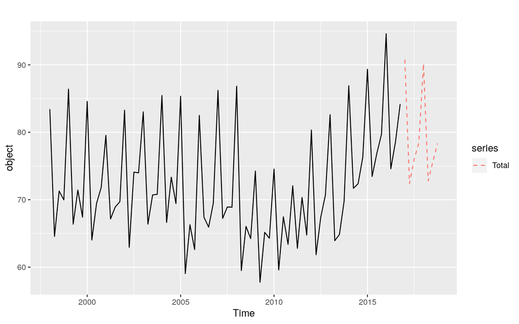

```r
autoplot(aggts(tourism.hts, level=0)) +
  autolayer(aggts(visnightsfc, level=0), lty=2)
```

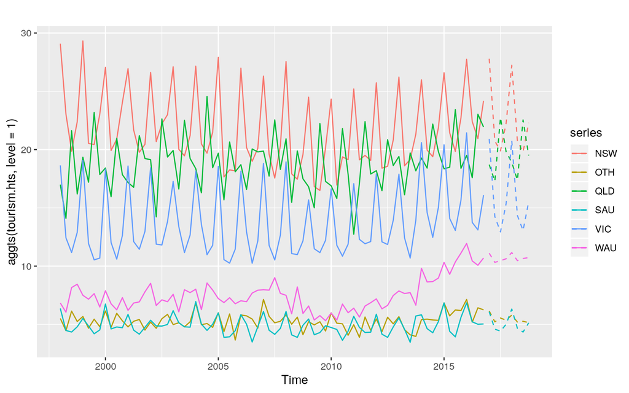

```r
autoplot(aggts(tourism.hts, level=1)) +
  autolayer(aggts(visnightsfc, level=1), lty=2)
```

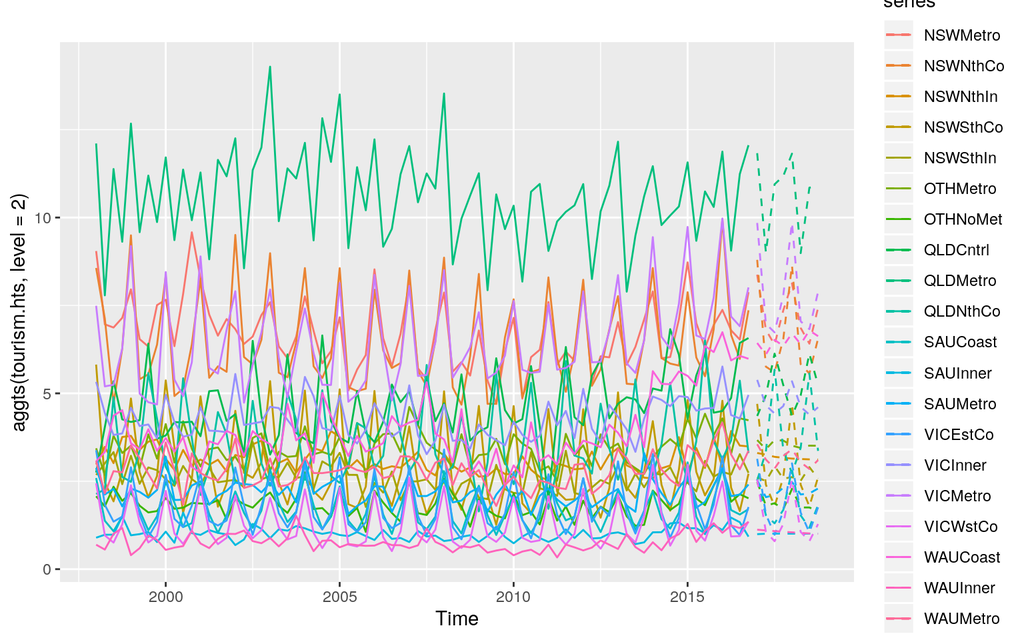

```r
autoplot(aggts(tourism.hts, level=2)) +
  autolayer(aggts(visnightsfc, level=2), lty=2)
```

The forecasts look too low for the Total and NSW. It seems that the bottom-up forecasts miss the strong trend after 2010 observed for some series. For most other states and the zones, the trends and seasonality have been captured and the forecasts look believable.

Below we further explore the forecasts for the largest 4 states.

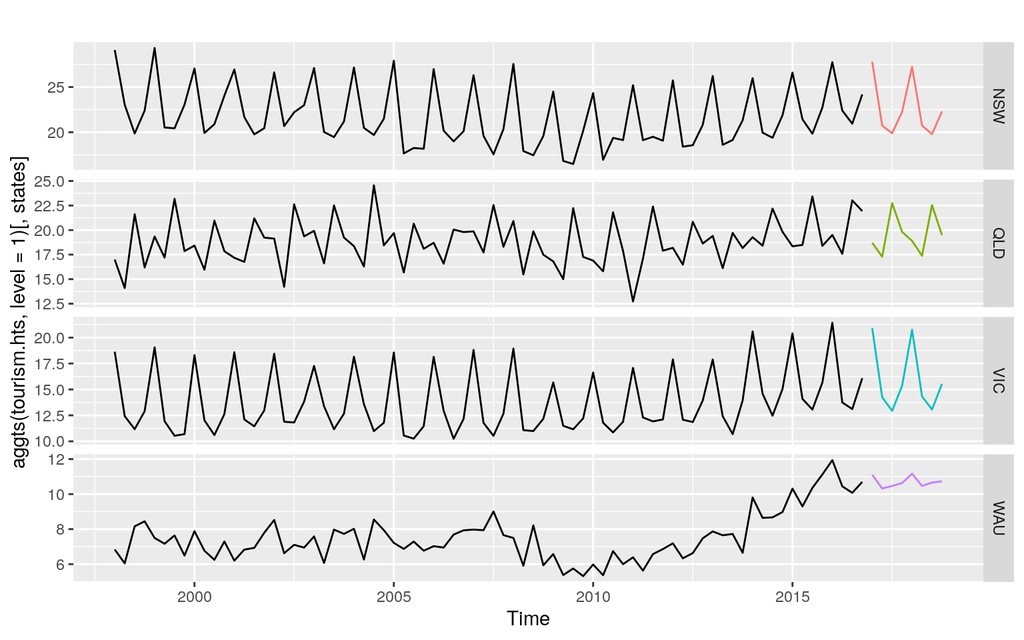

```r
states <- c("NSW","QLD","VIC","WAU")
autoplot(aggts(tourism.hts, level=1)[,states],facets=TRUE) +
  autolayer(aggts(visnightsfc, level=1)[,states]) +
  guides(color=FALSE)
```

# Ex 3

> Model the aggregate series for Australian domestic tourism data `visnights` using an ARIMA model. Comment on the model. Generate and plot 8-step-ahead forecasts from the ARIMA model and compare these with the bottom-up forecasts generated in question 2 for the aggregate level.

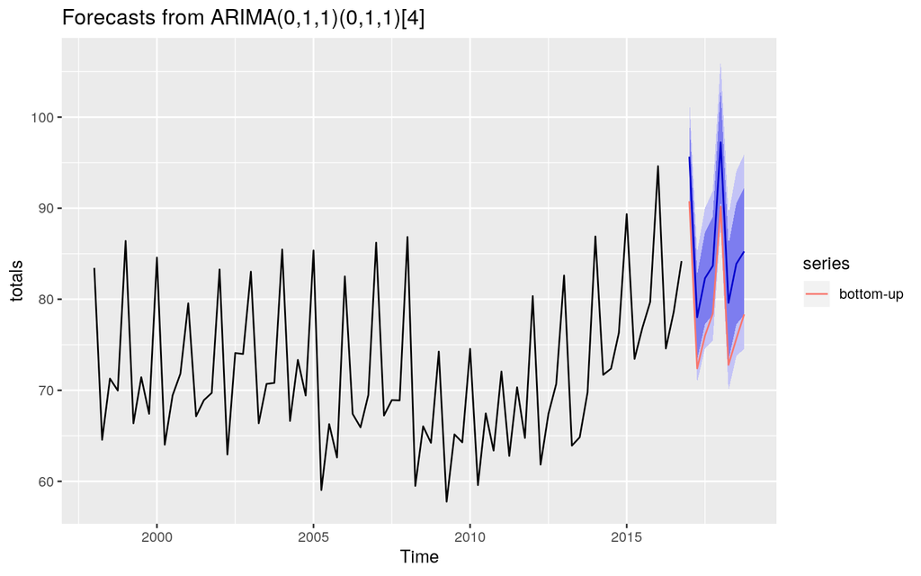

```r
tourism.hts <- hts(visnights, characters = c(3, 5))
totals <- aggts(tourism.hts, level=0)[,1L]
fit <- auto.arima(totals)
fc <- forecast(fit, h=8)
autoplot(fc) +
  autolayer(aggts(visnightsfc, level=0), series="bottom-up")
```

The bottom-up forecasts are much lower, and given the increasing trend at the end of the series, the forecasts based on the aggregate series look much better.

# Ex 4

> Generate 8-step-ahead optimally reconciled coherent forecasts using ARIMA base forecasts for the `visnights` Australian domestic tourism data. Plot the coherent forecasts by level and comment on their nature. How and why are these different to the bottom-up forecasts generated in question 2 above.

```r
tourism.hts <- hts(visnights, characters = c(3, 5))
visnightsfc2 <- forecast(tourism.hts, fmethod='arima', h=8)
```

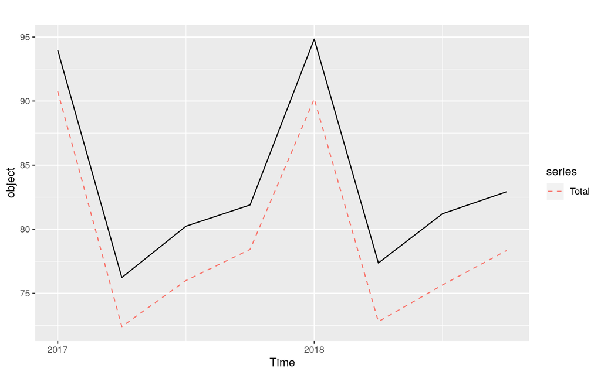

```r
autoplot(aggts(visnightsfc2, level=0)) +
  autolayer(aggts(visnightsfc, level=0), lty=2)
```

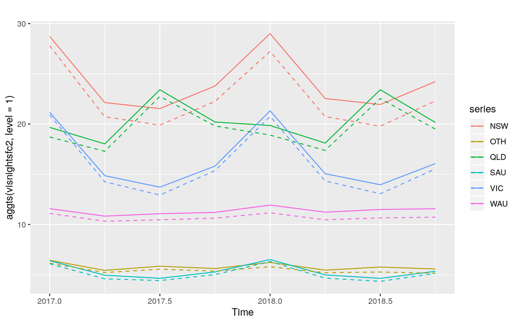

```r
autoplot(aggts(visnightsfc2, level=1)) +
  autolayer(aggts(visnightsfc, level=1), lty=2)
```

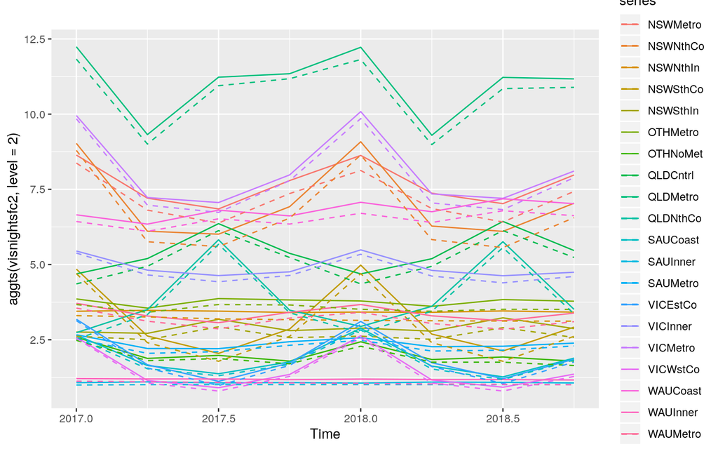

```r
autoplot(aggts(visnightsfc2, level=2)) +
  autolayer(aggts(visnightsfc, level=2), lty=2)
```

All of the bottom-up forecasts are lower than the reconciled forecasts. Because the trends are relatively weak at the zone level, they have not been captured by the models used by the bottom-up approach. When these are added up, the problem becomes obvious. Using the reconciliation approach, the trends are captured at the upper levels, and then the lower forecasts are adjusted accordingly.

# Ex 5

> Using the last two years of the `visnights` Australian domestic tourism data as a test set, generate bottom-up, top-down and optimally reconciled forecasts for this period and compare their accuracy.

```r
tourism.hts <- hts(visnights, characters = c(3, 5))
train <- window(tourism.hts, end=c(2014,4))
visnightsfc_bu <- forecast(tourism.hts, fmethod='arima', h=8, method="bu")
visnightsfc_td <- forecast(tourism.hts, fmethod='arima', h=8, method="tdfp")
visnightsfc_opt <- forecast(tourism.hts, fmethod='arima', h=8, method="comb")
```

```r
test <- window(tourism.hts, start=2015)
acc <- cbind(
`Bottom-up` = accuracy(visnightsfc_bu, test)["RMSE",],
`Top-down` = accuracy(visnightsfc_td, test)["RMSE",],
`Reconciled` = accuracy(visnightsfc_opt, test)["RMSE",])
# Level 0
acc[1,]
```

```
##  Bottom-up   Top-down Reconciled
##     2.9840     4.5735     2.7780
```

```r
# Level 1
colMeans(acc[2:7,])
```

```
##  Bottom-up   Top-down Reconciled
##    0.78723    1.07660    0.82823
```

```r
# Level 2
colMeans(acc[8:27,])
```

```
##  Bottom-up   Top-down Reconciled
##    0.36031    0.42862    0.36760
```

In this case, the reconciled method is best for the top-level, but the bottom-up method is more accurate, on average, for the zones and states.

Looking more closely at the states:

```r
acc[2:7,]
```

```
##     Bottom-up Top-down Reconciled
## NSW   1.12163  2.04572    1.20563
## OTH   0.88422  0.47686    0.56328
## QLD   1.15450  1.17551    1.05851
## SAU   0.53021  0.43535    0.43599
## VIC   0.43291  1.04073    0.71430
## WAU   0.59994  1.28543    0.99167
```